# Simple Linear Regression

MATH 325 - Brother Saunders

Andrew Seaman

02-10-2026

## Introduction

### Background

**Data Collection with Apple Devices**

The iPhone [^1] (*June 29, 2007*) in tandem with the Apple Watch [^2](*April 24,2015*) record numerous health metrics for the user/wearer made accessible in the IOS Health App [^3] (*September 17, 2014*). Per Apple’s promotions, users are intended to use these metrics to set goals and train more effectively. Two intriguing metric to avid and casual health conscious users alike is daily total step count and average heart rate. Measurements are more accurate for individuals who use an Apple Watch because wearable devices tend to be on the user’s person more consistently than an iPhone especially during exercise when a lot of valuable data is collected. In particular, Heart Rate can’t be recorded with an iPhone alone.

**Device Use History**

The subject of this study, who is also the author, first began collecting health metrics in the late 2010s. Below is a timeline of device acquisition and subsequent use:

1. Sep 2017 - iPhone SE [^4]
2. Jun 2019 - iPhone 7 [^5]
3. Oct 2022 - iPhone 12 Pro [^6]
4. Jul 2024 - Apple Watch 1 [^7]
5. Jan 2025 - iPhone 16 Pro Max [^8]
6. Feb 2025 - Apple Watch 10 [^9]

### Setup

First, several code libraries were used to perform the statistical tests.

**Libraries**

These **libraries** are used to reproduce this analysis.

```r
# Libraries
library(tidyverse)
library(mosaic)
library(car)
library(pander)
library(readr) # Used to import the data
library(scales) # Needed? ChatGPT gave it to me when helping me write the big plotting function (jitter-box-line-plot 1 and 2)
library(directlabels)
#library(lubridate) # For date extraction in the 2nd plot of the Graphics section
```

Next, the author’s health data was imported and cleaned to improve readability.

**Data**

This **data** is imported locally and the date field data type is set to a date type.

```r
# Data import
# file_path <- "../../Data/iosHealth/health_export_2026-01-12.csv"
# health <- read_csv(file_path, col_types = cols(Date = col_date(format = "%m/%d/%y")))

health <- read_csv("../../Data/iosHealth/IOS_health_2017-2026.csv",
    col_types = cols(Date = col_date(format = "%m/%d/%y")))
#  [1] "Date"
#  [2] "Cycling Distance (sum)"
#  [3] "Exercise Minutes (sum)"
#  [4] "Lean Body Mass (most recent)"
#  [5] "Walking/Running Distance (sum)"
#  [6] "Walking HR Avg (average)"
#  [7] "Mindful Minutes (sum)"
#  [8] "Body Temperature (Average) (average)"
#  [9] "Basal Energy (sum)"
# [10] "Blood Glucose (Most Recent) (most recent)"
# [11] "Heart Rate (average)"
# [12] "Flights Climbed (sum)"
# [13] "Headphone Audio (average)"
# [14] "Respiratory Rate (average)"
# [15] "Body Fat % (most recent)"
# [16] "Environmental Audio (average)"
# [17] "Swimming Distance (sum)"
# [18] "Blood Oxygen (average)"
# [19] "Body Temperature (Most Recent) (most recent)"
# [20] "Sleep (sum)"
# [21] "BP Diastolic (Average) (average)"
# [22] "VO2 Max (most recent)"
# [23] "BP Systolic (Most Recent) (most recent)"
# [24] "BP Systolic (Average) (average)"
# [25] "Blood Glucose (Average) (average)"
# [26] "Sleep (Core) (sum)"
# [27] "Total Energy (sum)"
# [28] "HRV (SDNN) (average)"
# [29] "BP Diastolic (Most Recent) (most recent)"
# [30] "Steps (sum)"
# [31] "Weight (Most Recent) (most recent)"
# [32] "Resting Heart Rate (average)"
# [33] "Sleep (REM) (sum)"
# [34] "Sleep (Asleep) (sum)"
# [35] "Sleep (Deep) (sum)"
```

Lastly, the original **column names** were cleaned up.

```r
# > Select columns, filter by year, and rename fields
health <- health %>%
  rename(
    HeartRate = `Heart Rate (average)`,
    Steps = `Steps (sum)`
  ) %>%
  select(Date, HeartRate, Steps) %>%
# > Only use data from 2023-2026
  filter(year(Date) >= 2023)
```

```r
health <- mutate(health, Year = year(Date))
```

## Analysis

#### Hypothesis

$$\underbrace{Y_i}_\text{Total Steps} = \beta_0 + \beta_1
\underbrace{X_i}_\text{Avg Heart Rate} + \epsilon_i \quad \text{where} \
\epsilon_i \sim N(0, \sigma^2)$$

The hypotheses below closely observe the **true slope** of the regression model, $\beta_1$. If $\beta_1$ is 0, then we’re confident that between *Avg Heart Rate* and reported *Total Steps* there is not a meaningful relationship. The linear regression model would be considered neither positive nor negative but *dead* where the one variables does not impact the other.

$$H_0: \beta_1 = 0 \\
H_a: \beta_1 \neq 0 \\
\alpha = 0.1$$

#### Graphics

First, we’ll plot each variable independently and look at the variance year-over-year (YoY) before comparing the variables against each other looking for covariance where one variable affects the other.

```r
# 1) Function: df of means by Year
df_means <- function(df, var) {
  df %>%
    filter(!is.na({{ var }}), !is.na(Year)) %>%
    group_by(Year) %>%
    summarize(mean = mean({{ var }}, na.rm = TRUE), .groups = "drop")
}



# 2) Function: counts of non-missing points by Year
df_counts <- function(df, var) {
  df %>%
    filter(!is.na({{ var }}), !is.na(Year)) %>%
    count(Year, name = "Points")
}



# 3) Function: Jitter Box Line Plot
# > Function start and parameters       ylimits: optional parameter
jitter_box_line_plot <- function(df, var, title, subtitle, ylab, xlab) {
# > Clean dataframe
  df_clean <- df %>%
    filter(!is.na({{ var }}), !is.na(Year))
# > Order years
  year_levels <- sort(unique(df_clean$Year))
# > Base plot
  ggplot(df_clean, aes(x = factor(Year), y = {{ var }}, color = factor(Year))) +
#   > Boxplot
    geom_boxplot(outlier.alpha = 0) +
#   > Jitter plot
    geom_jitter(alpha = 0.2, width = 0.2) +
#   > Line of means
    geom_line(
      data = df_means(df, {{ var }}),
      aes(x = factor(Year), y = mean, group = 1),
      inherit.aes = FALSE
    ) +
#   > Specify upper y-axis max limit
    # scale_y_continuous(limits = {{ylimits}})+
#   > Counts
    geom_label(
      data = df_counts(df, {{ var }}),
      aes(x = factor(Year), y = Inf, label = Points),
      vjust = 1.5,
      show.legend = FALSE,
      inherit.aes = FALSE
    ) +
#   > Label for counts
    annotate(
      "text",
      x = as.character(min(year_levels)),  # leftmost year (factor-safe)
      y = Inf,
      label = "Points:",
      vjust = 2.2,
      hjust = 1.5
    ) +
#   > Labels
    labs(title = title, subtitle = subtitle, y = ylab, x = xlab) +
#   > Color scale
    scale_color_brewer(palette = "Set1", name = "Year") +
#   > Base theme
    theme_bw() +
#   > Custom theme
    theme(
      legend.position = "none",
      plot.margin = margin(10, 30, 10, 10)
    ) +
#   > ??
    coord_cartesian(clip = "off")
}
```

Variable: **`Heart Rate`**

In the plot below, 2026 shows three things of note:

1. High right skew or greater spread in the upper 50% of the data about twice that of other years.
2. The median is higher than for others years.
3. The mean is much further away (above) from the median than for other years.

Additionally, because the subject had sporadic access to heart rate measuring devices until mid-2024 data collection is scarce in 2023.

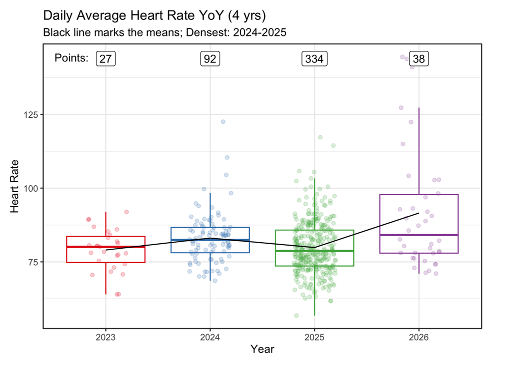

```r
jitter_box_line_plot(
  health,
  HeartRate,
  # c(50,175),
  "Daily Average Heart Rate YoY (4 yrs)",
  "Black line marks the means; Densest: 2024-2025",
  "Heart Rate",
  "Year"
)
```

Variable: **`Steps`**

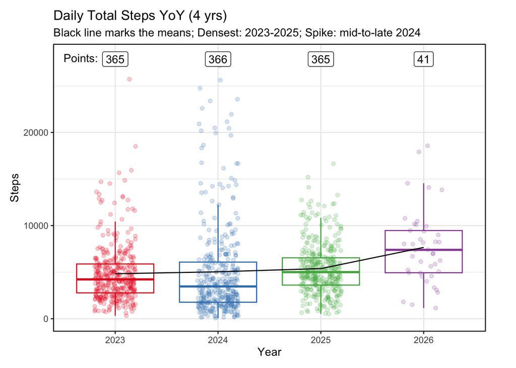

```r
jitter_box_line_plot(
  health,
  Steps,
  # c(0,30000),
  "Daily Total Steps YoY (4 yrs)",
  "Black line marks the means; Densest: 2023-2025; Spike: mid-to-late 2024",
  "Steps",
  "Year"
)
```

Although the plots above hint at a time trend in the data, returning to the primary focus of this analysis the plot below models the linear relationship between heart rate and steps. We see a positive correlation (blue line) that passes through the intersection of $\bar{x}$ and $\bar{y}$ (red lines) as expected.

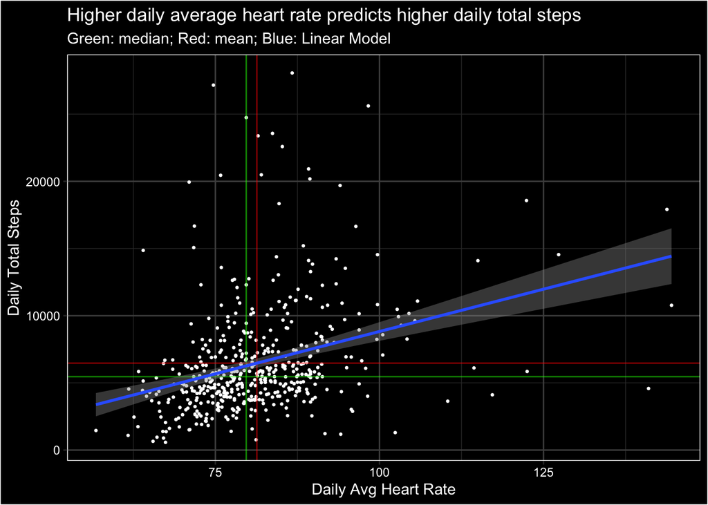

```r
# NOTE FOR BROTHER SAUNDERS (2/17/26):
#   - I figured out why the lm (blue line) didn't pass through xbar and y bar (red lines intersection)
#   - The means, medians, and lm were all calculated using different subsets.
#   - If a row had Heart Rate but not steps the mean and median line would include that row.
#   - However, lm requires both Heart Rate and Steps to have a value (or be finte) for plotting


# Clean df where both variables have value in the same row
df_finite <- health %>%
  filter(is.finite(HeartRate), is.finite(Steps))

# Line colors
meanR_medianG <- c("red","green")



# > Plot Start
ggplot(df_finite, aes(x = HeartRate, y = Steps)) +
# > Scatterplot
  geom_point(color = "white", pch = 19, size = 0.5) +
# > Base theme
  theme_bw() +
# > Custom theme
  theme(
#   > Black background and white border
    panel.background = element_rect(fill = "black"),
    plot.background  = element_rect(fill = "black"),
    panel.border     = element_rect(color = "white"),
#   > White text
    text = element_text(color = "white"),
    axis.text = element_text(color = "white"),
    axis.title = element_text(color = "white"),
#   > Grey grid lines
    panel.grid.major = element_line(color = "grey30"),
    panel.grid.minor = element_line(color = "grey20"),
    legend.background = element_rect(fill = "black", color = NA)
    # legend.position = "none"
  )+
# > Custom titles/labels
  labs(
    title = "Higher daily average heart rate predicts higher daily total steps",
    subtitle = "Green: median; Red: mean; Blue: Linear Model",
    x = "Daily Avg Heart Rate",
    y = "Daily Total Steps")+
# > Vertical Lines
  geom_vline(
    xintercept = c(mean(df_finite$HeartRate), median(df_finite$HeartRate)),
    color = meanR_medianG,
    alpha = .5)+
# > Horizontal Lines
  geom_hline(
    yintercept = c(mean(df_finite$Steps), median(df_finite$Steps)),
    color = meanR_medianG,
    alpha = .5)+
# > Linear Model Line
  geom_smooth(method = "lm")
```

## Test

> Simple Model Summary

```r
# Variables: Y = Steps; X = Heart Rate
mylm <- lm(Steps ~ HeartRate, data = health)
mylm_summary <- summary(mylm)

# > VALUES:

# 1) Estimated Y-Int
est_y_stp <- mylm_summary$coefficients["(Intercept)", "Estimate"]
est_y_stp_fmt <- round(est_y_stp, digits = 0)

# 2)
est_y_hr <- mylm_summary$coefficients["HeartRate", "Estimate"]
est_y_hr_fmt <- round(est_y_hr, digits = 0)

# 3) p-value for HeartRate
pval <- mylm_summary$coefficients["HeartRate", "Pr(>|t|)"]
pval_fmt <- formatC(pval, format = "e", digits = 2)

# 4) R^2
r_sqr <- mylm_summary$r.squared
r_sqr_fmt <- formatC(r_sqr, digits = 3)
```

Below we examine the summary of the simple linear regression model, where daily total steps are modeled as a function of average heart rate. The intercept (-3779) is not particularly meaningful in a practical sense, as it represents the predicted number of steps when heart rate is zero—a scenario that is physiologically impossible. However, the slope coefficient is both interpretable and statistically significant. Specifically, the model estimates that the average number of steps this individual takes on a day is increased by 126 steps for each additional beat per minute (BPM) faster in daily average heart rate. The associated p-value is extremely small ($p \approx$ 1.05e-13), providing strong evidence against the null hypothesis of no relationship. While the model explains a modest portion of the total variability in steps ($R^2 \approx$ 0.107), the positive association between heart rate and steps is clear and statistically meaningful.

```r
# Variables: Y = Steps; X = Heart Rate
pander(mylm_summary)
```

|  | Estimate | Std. Error | t value | Pr(>\|t\|) |
| --- | --- | --- | --- | --- |
| **(Intercept)** | -3779 | 1350 | -2.798 | 0.005337 |
| **HeartRate** | 126 | 16.47 | 7.653 | 1.052e-13 |

Fitting linear model: Steps ~ HeartRate

| Observations | Residual Std. Error | $R^2$ | Adjusted $R^2$ |
| --- | --- | --- | --- |
| 491 | 3882 | 0.107 | 0.1051 |

$$\underbrace{\hat{Y}_i}_\text{Est. Total Steps} =
\overbrace{-3779.184}^\text{est. y-int} + \overbrace{126.022}^\text{est.
slope} \underbrace{X_i}_\text{Heart Rate}$$

> Diagnostic Plots

**Residuals vs. Fitted**

**Q-Q Residuals**

The Q–Q residuals plot indicates a substantial departure from normality, particularly in the upper tail. While residuals near the center of the distribution align reasonably well with the theoretical normal line, the largest residuals deviate sharply upward. This pattern reflects a heavy right tail in the error distribution, likely driven by days with unusually high step counts. As a result, the normality assumption underlying standard inference for the linear regression model is **violated**.

**Residuals vs. Index**

There is **no obvious bias** since the residuals are more or less centered around zero. However, early high spikes and a tighter grouping later indicate that while there is a relationship in the data the model is noisy and doesn’t provide the clearest inference capability.

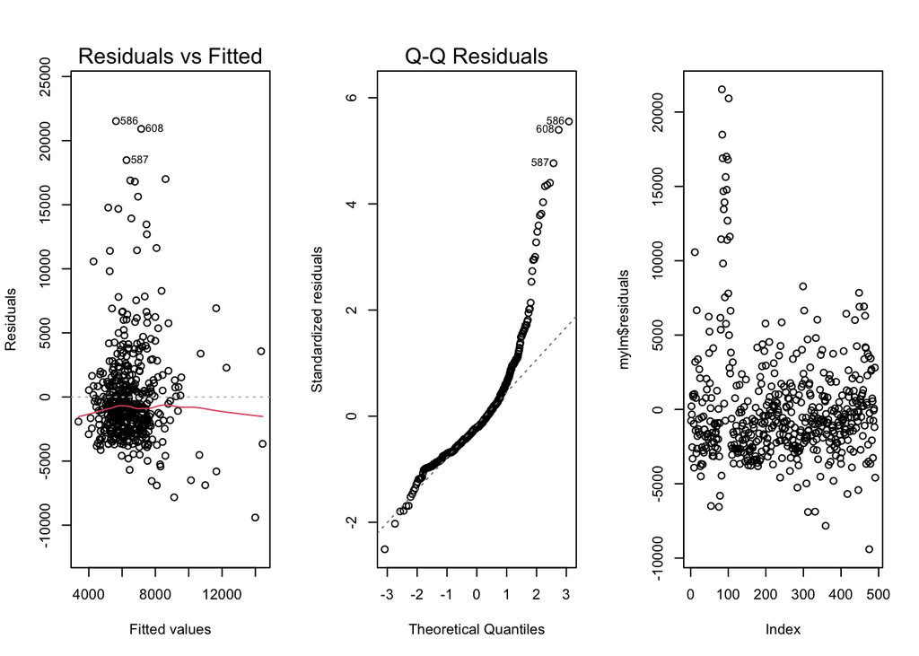

```r
# > Plots 1-3
par(mfrow=c(1,3))
plot(mylm,which=1:2)
plot(mylm$residuals)
```

> Footnotes
[^1]: [iPhone](https://www.apple.com/iphone/)
[^2]: [Apple Watch](https://www.apple.com/watch/)
[^3]: [iOS Health App](https://www.apple.com/health/)
[^4]: [iPhone SE](https://support.apple.com/en-us/112005)
[^5]: [iPhone](https://support.apple.com/en-us/111943)
[^6]: [iPhone 12 Pro](https://support.apple.com/en-us/111875)
[^7]: [Apple Watch 1](https://support.apple.com/en-us/111985)
[^8]: [iPhone 16 Pro Max](https://support.apple.com/en-us/121032)
[^9]: [Apple Watch Series 10](https://support.apple.com/en-us/121202)